# Facial Emotion Recognition by Linear Discriminant Analysis

Group 8

10/22/2019

## **Abstract**

In this project, we created a classification engine for facial emotion recognition. After testing a variety of different models, we verified that using LDA with a PCA-driven dimensional reduction offered the best improvement over the baseline model of gradient boosting machines.

[output not shown]

## **Step 1: set up controls for evaluation experiments**

```r
setwd("/Users/mengyang/Documents/GitHub/fall2019-proj3-sec2--grp8/doc")
train_dir <- "../data/train_set/"
train_image_dir <- paste(train_dir, "images/", sep="")
train_pt_dir <- paste(train_dir,  "points/", sep="")
train_label_path <- paste(train_dir, "label.csv", sep="")

run.cv=FALSE # run cross-validation on the training set
K <- 5  # number of CV folds
run.feature.train=TRUE # process features for training set
```

## **Step 2: import data and train-test split**

```r
#train-test split
set.seed(10)
info <- read.csv(train_label_path)
n <- nrow(info)
n_train <- round(n*(4/5), 0)
train_idx <- sample(info$Index, n_train, replace = F)
test_idx <- setdiff(info$Index,train_idx)
```

```r
#function to read fiducial points
#input: index
#output: matrix of fiducial points corresponding to the index
n_files <- length(list.files(train_image_dir))
readMat.matrix <- function(index){
     return(round(readMat(paste0(train_pt_dir, sprintf("%04d", index), ".mat"))[[1]],0))
}

#load fiducial points
fiducial_pt_list <- lapply(1:n_files, readMat.matrix)
save(fiducial_pt_list, file="../output/fiducial_pt_list.RData")
```

```r
load("../output/fiducial_pt_list.RData")
```

## **Step 3: baseline model**

### Step 3.1: feature construction

This step is converting 78 fiducial points to distances as 6006 features (3003 horizontal distances and 3003 vertical distances).

```r
if(run.feature.train){

  source("../lib/feature.R")
  base.feature.construction.start = proc.time()
  tm_feature_train <- NA
  dat_train_base <- feature(fiducial_pt_list, train_idx)
  base.feature.construction.train.end = proc.time()

  tm_feature_test <- NA
  dat_test_base <- feature(fiducial_pt_list, test_idx)
  base.feature.construction.test.end = proc.time()

  #time for training feature construction
  print(base.feature.construction.train.end - base.feature.construction.start)
  #time for test feature construction
  print(base.feature.construction.test.end - base.feature.construction.train.end)

  save(dat_train_base, file="../output/feature_train_base.RData")
  save(dat_test_base, file="../output/feature_test_base.RData")

}
```

```
##    user  system elapsed
##   2.235   0.610   3.066
##    user  system elapsed
##   0.273   0.125   0.423
```

### Step 3.2: load feature

```r
load("../output/feature_train_base.Rdata")
load("../output/feature_test_base.Rdata")
```

### Step 3.3: baseline model: gradient boosting machine

```r
#gbm classifier
base.train.model.start = proc.time()
baseline=gbm(emotion_idx~. ,data =dat_train_base ,distribution = "multinomial",n.trees = 100,
             shrinkage = 0.02,n.minobsinnode = 15,cv.folds = 5)
base.train.model.end = proc.time()
#time for training the baseline model
print(base.train.model.end - base.train.model.start)
```

```
##     user   system  elapsed
##  451.801   10.485 1417.157
```

```r
#predict on test data
base.test.start = proc.time()
baseline.pred = predict.gbm(object = baseline,
                   newdata = dat_test_base,
                   n.trees = 100,
                   type = "response")
base.test.end = proc.time()
#time for testing the baseline model
print(base.test.end - base.test.start)
```

```
##    user  system elapsed
##  17.662   0.788  18.637
```

```r
#prediction result
baseline.labels = colnames(baseline.pred)[apply(baseline.pred, 1, which.max)]
baseline.cm = confusionMatrix(dat_test_base$emotion_idx, as.factor(as.numeric(baseline.labels)))
print(baseline.cm$byClass[1])
```

```
## [1] 0.4333333
```

```r
print(baseline.cm$table)
```

```
##           Reference
## Prediction  1  2  3  4  5  6  7  8  9 10 11 12 13 14 15 16 17 18 19 20 21
##         1  13  0  2  1  0  0  0  0  0  5  0  0  1  0  0  1  0  1  0  0  0
##         2   0 12  0  0  0  0  0  3  5  0  0  0  0  0  0  0  0  0  0  3  0
##         3   3  0 14  1  0  1  0  1  0  3  0  0  0  0  0  3  0  0  1  0  0
##         4   2  0  2  8  0  3  2  0  0  5  0  1  4  0  0  0  0  0  0  0  0
##         5   0  0  0  0  8  0  2  0  0  0  0  0  0 10  3  0  1  3  0  0  0
##         6   2  0  2  1  0  8  1  0  0  0  0  2  2  0  0  0  0  0  0  0  0
##         7   0  0  0  0  1  0  4  0  0  0  0  0  0  1  0  1  3  0  3  0  4
##         8   0  4  0  0  0  0  0 12  2  0  0  0  0  0  0  0  4  0  0  1  0
##         9   0  2  0  0  1  1  0  5  4  1  0  0  0  0  0  0  0  0  0  3  1
##         10  1  0  4  4  0  0  0  0  0  4  0  1  3  0  0  0  0  0  0  0  1
##         11  2  0  3  1  0  6  0  0  0  0  3  4  1  0  0  0  0  0  0  1  0
##         12  3  0  6  0  0  4  0  0  1  2  2  4  4  0  0  2  0  0  1  0  0
##         13  1  0  2  2  0  0  0  0  1  1  2  1  1  0  0  0  0  0  0  1  1
```

[output cut: 33 more lines]

### **Step 4: our improved model**

### Step 4.1: construct features and responses

In this part, we did feature selection by deleting the duplicated fiducial points on the right face. We did this because:

- 1. We can recognize someone’s emotion only through his/ her left face and the middle part.
- 2. If one’s face is not symmetric, then we believe the imbalance in the face is an error term in the model, and deleting the duplicates will not change the model.
- 3. If one’s face is symmetric, then for the features construction, we only need the left face and the middle points. Because for any distances on the right, they have corresponding points on the left which give the same distances.
- 4. For any distance between a left point A and a right point B, its horizontal distance can be measured by ( distance (A, middle) + distance (B’s corresponding point on the left, middle) ), and its vertical distances can be measured by ( distance(A, B’s corresponding point on the left) )

After deleting the 34 fiducial points on the right, we still have 44 fiducial points (34 on the left and 10 in the middle) for each image, which will result to $44\times43=1892$ features. 1892 is still too much for PCA, our next step for dimensional reduction. Because when tuning the parameter (number of principle components selected) by 5-fold cross validation, we only have 1600 data (80% training dataset) to train the model, which are not enough (with p=1892 larger than n=1600) to construct a stable covariance matrix in PCA.

So in the next step, we deleted the duplicated 306 ($34\times9$) features, because for each point among the 34 points on the left, the horizontal distances between it and the 10 points in the middle are all the same. We just kept one of them for each of the 34 left points to reduce the dimension.

We can also take a look at the following picture. It is the average 6006 features of emotion 1, and we can see some duplicates between the red lines, so it’s reasonable to delete those duplicates.

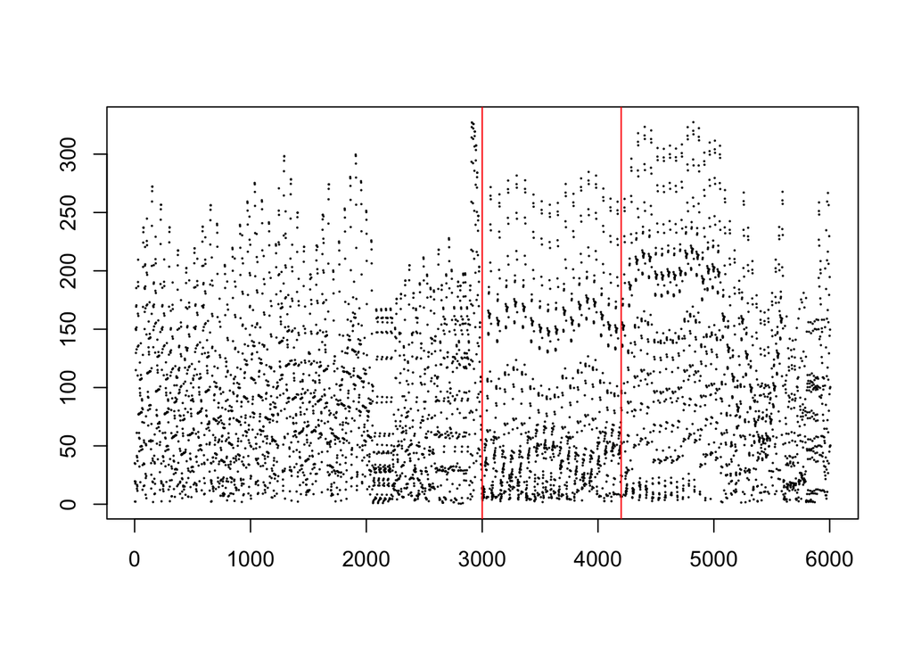

```r
plot(colMeans(dat_train_base[dat_train_base$emotion_idx=="1",-6007]),
     cex=.1, main="", ylab="", xlab="")
abline(v = c(3000, 4200), col=2)
```

```r
feature.construction.start = proc.time()
#delete the duplicated right face
leftmid_idx <- c(1:9,19:26,35:44,50:52,56:59,62,63,64:71)
fiducial_pt_list_lm <- lapply(fiducial_pt_list, function(mat){return(mat[leftmid_idx,])})

#306 duplicates index
n.m <- 44
middle <- c(18:21,27,30,31,34,35,44)
d <- rep(1, 946)
m=matrix(rep(0, n.m^2),n.m,n.m,byrow=T)
k=1
for(i in 1:(n.m-1))for(j in (i+1):n.m){
  m[i,j] <- m[j,i] <- d[k]
  k=k+1
}
m[middle,] <- -1
m[,middle] <- -1
m[middle,middle] <- -2
ind <- c()
k=1
for(i in 1:(n.m-1)) for(j in (i+1):n.m){
  if(m[j,i] == -1) ind <- c(ind, k)
  k=k+1
}
dup_horiz <- ind[!(ind %in% cumsum(43:1)[-middle])]
```

```r
if(run.feature.train){

  source("../lib/feature.R")
  tm_feature_train <- NA
  dat_train <- feature(fiducial_pt_list_lm, train_idx)
  feature.construction.train.end = proc.time()

  dat_train <- dat_train[,-dup_horiz]
  feature.construction.train.end = proc.time()

  tm_feature_test <- NA
  dat_test <- feature(fiducial_pt_list_lm, test_idx)
  feature.construction.test.end = proc.time()

  dat_test <- dat_test[,-dup_horiz]
  feature.construction.test.end = proc.time()

  #time for training feature construction
  print(feature.construction.train.end - feature.construction.start)
  #time for test feature construction
  print(feature.construction.test.end - feature.construction.train.end)

  save(dat_train, file="../output/feature_train.RData")
  save(dat_test, file="../output/feature_test.RData")

}
```

```
##    user  system elapsed
##   0.663   0.335   1.066
##    user  system elapsed
##   0.083   0.012   0.096
```

### Step 4.2: load features

```r
load("../output/feature_train.RData")
load("../output/feature_test.RData")
```

### Step 4.3: cross validation for number of principle components

We tuned the first 30, 50, 75, 120, 150, 200 principle components with proportions of variance of about 50%, 60%, 70%, 80% ,85% and 90% respectively.

To choose the best number of principal components among these 6 numbers, we used 5-folder cross validation.

We got the highest cross validation accuracy with 50 PCs, and the cross validation accuracy is as below.

| number of PCs | proportion of variance | cross validation accuracy |
| --- | --- | --- |
| 30 | 50.1% | 44.3% |
| 50 | 61.1% | 46.6% |
| 75 | 70.2% | 45.9% |
| 120 | 81.0% | 45.6% |
| 150 | 85.9% | 45.6% |
| 200 | 91.2% | 43.3% |

```r
pca <- princomp(dat_train[,-1587], cor=T)
```

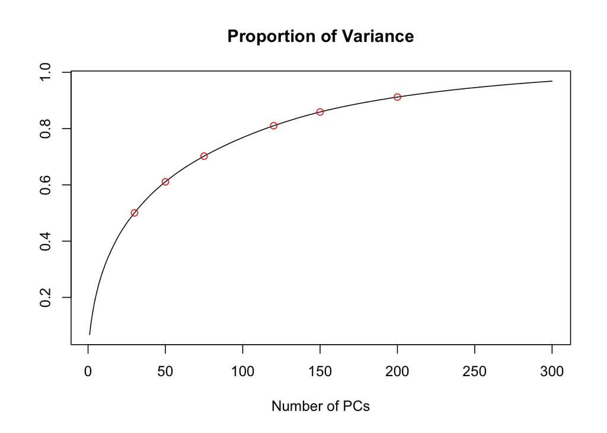

```r
plot(cumsum(pca$sdev)[1:300] / sum(pca$sdev), type = "l",
     main = "Proportion of Variance", ylab = "", xlab = "Number of PCs")
n.pc.list <- c(30,50,75,120,150,200)
for (n.pc in n.pc.list) points(n.pc, (sum(pca$sdev[1:n.pc]) / sum(pca$sdev)), col="red")
```

```r
if(run.cv){

set.seed(10)
cv.k <- createFolds(1:2000, k = K)
n.pc.list <- c(30,50,75,120,150,200)
cv.accuracy <- c()

for (f in cv.k){
  dat_train_cv <- dat_train[-f,]
  dat_validation_cv <- dat_train[f,]
  cv.tuning <- c()
  for (n.pc in n.pc.list){
    #pca
    pca <- princomp(dat_train_cv[,-1587], cor=T)
    train_x_pca <- data.frame(pca$scores[,1:n.pc])
    train_y <- dat_train_cv[1587]
    test_y <- dat_validation_cv[1587]
    colnames(train_x_pca) <- c(1:n.pc)
    train_pca <- cbind(train_x_pca, train_y)
    test_x_pca <- data.frame(predict(pca, dat_validation_cv[,-1587])[,1:n.pc])
    colnames(test_x_pca) <- c(1:n.pc)
    test_pca <- cbind(test_x_pca, test_y)
    train <- train_pca
    test <- test_pca
    #lda
    lda.model <- lda(emotion_idx ~ ., data=train)
    lda.test.pred = predict(lda.model, test[-dim(test)[2]])
    cv.tuning <- c(cv.tuning,
                     confusionMatrix(lda.test.pred$class, test$emotion_idx)$overall[1])
  }
  cv.accuracy <- cbind(cv.accuracy, cv.tuning)
}
colnames(cv.accuracy) <- 1:K
rownames(cv.accuracy) <- n.pc.list
cv.accuracy <- as.data.frame(cv.accuracy)
cv.accuracy$mean <- rowMeans(cv.accuracy)
cv.accuracy

}
```

### Step 4.4: principle components

The following pictures show us the features and first 20 principles components of emotion 2 and 3. In the feature plot, the difference of 1586 features between emotion 2 and 3 is a mess and it’s not significant, but it becomes easier to detect if we use principle components as our features.

```r
train.model.start = proc.time()
pca <- princomp(dat_train[,-1587], cor=T)
```

```r
n.pc <- 50
train_x_pca <- data.frame(pca$scores[,1:n.pc])
train_y <- dat_train[1587]
test_y <- dat_test[1587]
colnames(train_x_pca) <- c(1:n.pc)
train_pca <- cbind(train_x_pca, train_y)
test_x_pca <- data.frame(predict(pca, dat_test[,-1587])[,1:n.pc])
colnames(test_x_pca) <- c(1:n.pc)
test_pca <- cbind(test_x_pca, test_y)
train <- train_pca
test <- test_pca
```

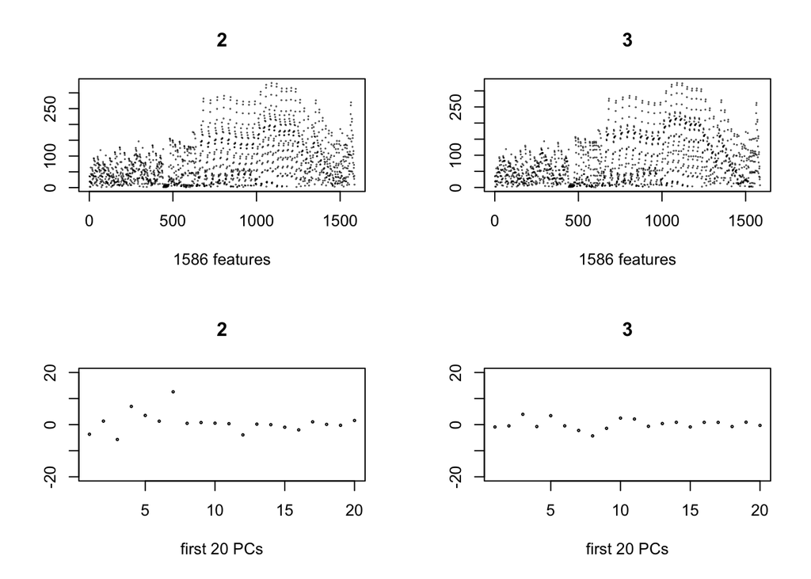

```r
par(mfrow=c(2, 2))
for(i in 2:3) plot(colMeans(dat_train[dat_train$emotion_idx==as.character(i),-1587]),
                  cex=.07, main=i,ylab="",xlab="1586 features")
for(i in 2:3) plot(colMeans(train[train$emotion_idx==as.character(i),-51])[1:20],
                   cex=.3, main=i,ylab="",xlab="first 20 PCs",ylim=c(-20,20))
```

### Step 4.5: linear discriminant analysis

```r
lda.model <- lda(emotion_idx ~ ., data=train)
train.model.end = proc.time()
#time for training the model
print(train.model.end - train.model.start)
```

```
##    user  system elapsed
##  15.423   0.393  16.174
```

```r
test.model.start = proc.time()
lda.test.pred = predict(lda.model, test[-dim(test)[2]])
test.model.end = proc.time()
#time for testing the model
print(test.model.end - test.model.start)
```

```
##    user  system elapsed
##   0.013   0.003   0.024
```

```r
#test accuracy
confusionMatrix(lda.test.pred$class, test$emotion_idx)$overall[1]
```

```
## Accuracy
##    0.512
```

```r
confusionMatrix(lda.test.pred$class, test$emotion_idx)$table
```

```
##           Reference
## Prediction  1  2  3  4  5  6  7  8  9 10 11 12 13 14 15 16 17 18 19 20 21
##         1  21  0  3  1  0  1  0  0  0  2  0  0  0  1  0  0  0  2  2  0  3
##         2   0 16  1  0  0  0  0  2  0  0  0  0  0  0  0  0  0  0  0  0  0
##         3   1  0 14  0  0  0  0  0  0  3  0  2  0  0  0  3  0  0  1  0  0
##         4   0  0  2 16  0  2  0  0  0  2  1  2  2  0  0  0  0  0  1  0  0
##         5   0  0  0  0 19  0  1  1  0  0  0  0  0  0  0  0  0  0  0  0  0
##         6   0  0  0  3  0 10  1  0  0  2  5  2  0  1  0  0  0  0  0  0  0
##         7   0  0  0  0  2  0  9  0  1  0  0  0  0  0  1  0  5  1  3  2  0
##         8   0  2  0  0  0  0  0 18  0  0  0  0  0  0  0  0  2  1  0  0  0
##         9   0  5  0  0  0  0  0  1 16  0  0  0  1  0  0  0  0  0  0  2  1
##         10  0  0  2  2  0  0  0  0  0  9  2  1  1  1  0  1  0  0  1  0  0
##         11  0  0  1  2  0  2  0  0  1  0  5  8  1  0  0  1  0  0  0  0  0
##         12  0  0  0  0  0  1  0  0  0  0  4 14  2  0  0  0  0  0  0  0  0
##         13  1  0  0  2  0  1  0  0  0  0  2  0  4  1  0  0  0  0  0  1  0
```

[output cut: 33 more lines]

### **Step 5: comparison and summary**

### Step 5.1: advantages of our improved model

- 1. High efficiency in both training and test step

- 2. Much higher prediction accuracy compared to baseline model

- 3. Robustness

### Step 5.2: comparison with quadratic discriminant analysis

LDA’s training accuracy and prediciton accuracy are 57.2% and 51.2%, while QDA’s are 99.5% and 20+%. It means QDA overfits the data.

Acctually, the difference within each group should be the same, because the difference within a group comes from the difference of people’s appearances in that group. However, the difference of people’s appearances within each group should be similar. There’s no reason that people in group 1 look similar, but people in group 2 look different.

### Step 5.3: comparison with boosting

What is more, boosting is sensitive to outliers, which means boosting methods are not as robust. In most boosting methods, the difference in training and test accuracy is larger than 20%, but in our model, the difference is only 6%. Such difference may not show how good a model is, but it may show the robustness in some way.